# Prosper loans dataset presentation

## by Sultan Alharbi

## Investigation Overview

The exploration focused on the reason behind taking a loan and what are Prosper ratings and what the customers of Prospers do for a living

## Dataset Overview

The data consists 113,937 loans from prosper with 81 variables on each loan. The subset of the dataset contains 113,066 loans and 13 variable that we will focus on in our analysis.

## The Prosper ratings

Prosper use a special metric they made to measure the ability of customers paying their loans without defualt, The ratings goes as follow : AA,A,B,C,D,E,HR , where AA is the safest choice for Prosper and HR is high risk customer in terms of completing the loan payments without a default.

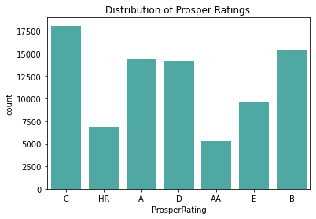

## What is the most common reason to take a loan ?

The number one reason that make a person take a loan, despte wether he is from the AA rated group or HR group is debt consolidation, which means that instead of having diffrent debts with diffrent intrest rates, you can group them into one larger loan istead of having multiple loans and debts.

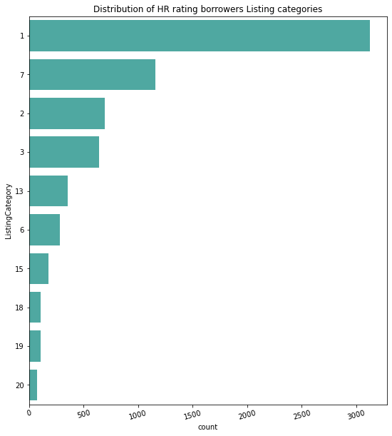

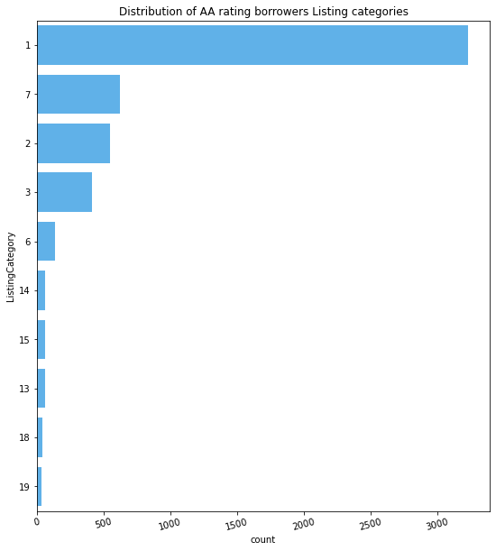

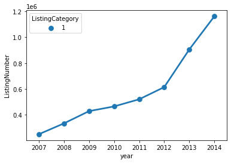

## Is there any relation between the income range and the Prosper rating?

The figure below shows us that most of AA customers income ranges from 100k dollar and above, while most of the HR customers income ranges from 25k to 49.9k.

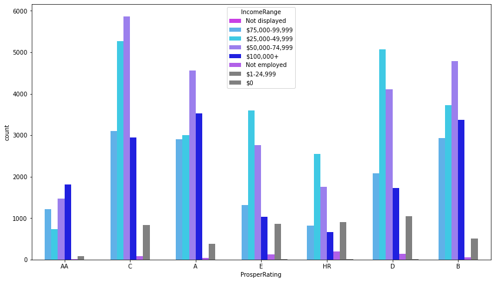